# R7: quanto sono troppo stretti gli intervalli dei valori veri presi da 5 aree per tessuto, e cambia qualche conclusione?

geo_spatialtrans, report di step (protocollo v2)

Published

November 9, 2026

# In breve

### In breve: quanto sono troppo stretti gli intervalli dei valori veri presi da 5 aree per tessuto, e cambia qualche conclusione?

**A cosa serviva.** Quasi tutti i valori veri con cui misuriamo il simulatore (densità e aree dei nuclei, trascritti per quadratino, tipi cellulari) vengono da 5 aree di 1 mm² per tessuto, e la loro incertezza è calcolata fra queste 5 aree. Le aree sono poche e in parte si sovrappongono. Volevamo sapere di quanto quegli intervalli sono troppo stretti, correggerli e vedere se qualche conclusione passata cambia, prima di confrontare il simulatore completo con i tessuti veri.

**Cosa abbiamo trovato.**

1. **Gli intervalli che usiamo contengono il valore vero del tessuto fra 76 e 84 volte su 100, non 95.**
   - La causa principale è il numero di aree: anche con 5 aree indipendenti si arriva solo a 84 su 100.
   - Le zone comuni peggiorano le cose dove sono più grandi: 76 su 100 nello stroma del tumore, 77 nel linfonodo.
   - L’intervallo fra la più bassa e la più alta delle 5 aree, che usiamo come margine, regge meglio: fra 89 e 94 su 100.
2. **Per tornare a 95 su 100 gli intervalli vanno allargati di circa 1,6-1,9 volte nel cuore, nel tumore del colon e nell’intestino, e di 2,6-3,2 volte nello stroma e nel linfonodo.**
   - Nei primi tre basta la geometria delle zone comuni.
   - Nello stroma e nel linfonodo il tessuto ha strutture di 270-480 µm, per esempio i follicoli del linfonodo. Così due aree che si toccano si somigliano molto più di quanto dice la sola parte in comune, e il fattore viene dalla struttura misurata dentro le aree.
   - Nel cervello di topo il fattore è 1,8 per i trascritti per quadratino e 3,9 per le misure sui nuclei. Quest’ultimo è incerto: la densità dei nuclei cambia su distanze più lunghe delle aree, e la stima va oltre i dati.
   - La correzione regge con valori a code pesanti. Non basta del tutto quando i valori delle aree sono molto asimmetrici, per esempio frazioni vicine a zero o tipi rari (24 intervalli su circa 240 controllabili): per quelli abbiamo calcolato un allargamento in più.
3. **Contare due volte i nuclei delle zone comuni non sposta i valori veri.** Lo spostamento è al più del 7 %, in una frazione molto piccola (i quadratini vuoti nel linfonodo), e sempre meno di metà dell’intervallo corretto. Vanno corretti gli intervalli, non i valori.
4. **Con gli intervalli corretti un verdetto passato su dieci cambia, ma nessuna scelta del simulatore oggi in uso è smentita.**
   - Su circa 7 900 verdetti di 29 step ne cambiano 709. Circa metà diventano non decisi; poco meno di metà diventano confermati, perché si allargano anche i margini veri. Nessun verdetto passa da confermato a smentito; 22 passano da non decisi a smentiti.
   - Quattro regole del livello cellulare ora finiscono in pareggio o con un punto di scarto, e per come erano scritte sceglierebbero l’altra variante. Riguardano come si assegna la taglia ai nuclei, la distanza minima fra nuclei vicini, la forma della variabilità delle taglie e le quote dei tipi. Anche la verifica finale delle cellule passa da confermata a non decisa (163 conferme, ne servivano 167). Ognuno dei quattro cambi di regola dipende da una sola riga o da un pareggio, e torna indietro con piccole variazioni della correzione. Quindi, con l’incertezza onesta, i dati non distinguono quelle varianti.
   - Il limite dichiarato «troppi nuclei a contatto nel tumore del colon e nel linfonodo» non regge più nel linfonodo, in nessuna delle letture corrette. Nel tumore del colon diventa non deciso o compatibile, secondo la lettura. Nello stroma la risposta dipende da come si calcola l’incertezza dei conteggi fatti a mano.
5. **Nel confronto finale del simulatore con i tessuti veri, gli intervalli dei trascritti per quadratino diventano molto più larghi nello stroma e nel linfonodo.** Per esempio, nello stroma i trascritti per quadratino da 8 µm passano da 260-350 a 144-431.

**Cosa devi decidere.**

1. **Adottiamo gli intervalli corretti come valori veri da qui in avanti, compreso il confronto finale? Consiglio di sì.**
   - Con quelli di oggi il simulatore risulterebbe «fuori dal vero» troppo spesso, per un difetto della misura e non suo. I fattori vengono dai dati, con regole scritte prima del calcolo e ricontrollate da quattro revisori.
   - Per i conteggi fatti a mano nelle finestre consiglio di prendere, fra il vecchio intervallo e quello corretto, il più largo: nello stroma quello corretto verrebbe più stretto di quanto permettono 60 nuclei contati.
   - Nel cervello, per le misure sui nuclei, consiglio il fattore grande, come dice la regola, segnato come incerto. Nel confronto finale conta poco, perché lì contano i trascritti per quadratino, che nel cervello cambiano del 3 %.
   - Alternativa: usare solo la correzione geometrica. È più semplice, ma nello stroma, nel linfonodo e nel cervello gli intervalli conterrebbero il valore vero solo fra 74 e 90 volte su 100.
   - Alternativa: tenere gli intervalli di oggi, che contengono il valore vero fra 76 e 84 volte su 100.
2. **Teniamo le varianti oggi in uso nel livello cellulare, scrivendo che i dati non le distinguono dalle alternative? Consiglio di sì.**
   - Le regole cambiano solo per pareggi o per un punto, e tornano indietro con piccole variazioni. Nessuna variante risulta migliore.
   - Alternativa: applicare le regole come sono scritte. Cambierebbero quattro scelte del modello che genera le cellule, e servirebbe uno step per ritarare e risimulare il livello cellulare, per un guadagno che i dati non mostrano.
   - Alternativa: raccogliere i dati che servono per distinguerle davvero, cioè almeno 10 aree disgiunte per tessuto e altre finestre contate a mano. La segmentazione costa poco; costano rifare le misure dei passi successivi e le tue ore di conteggio, che non ho stimato.
3. **Riscriviamo il limite dichiarato sui contatti fra nuclei come lo vedono ora i dati? Consiglio di sì.**
   - Diventerebbe: nel linfonodo nessun eccesso dimostrato; nel tumore del colon non deciso; nello stroma e per le coppie di nuclei a contatto il limite resta.
   - Alternativa: lasciarlo com’è fino a nuove finestre contate a mano.

**Comunque, nei prossimi step:**

- quando confronteremo il simulatore completo con i tessuti veri useremo la tabella dei valori veri corretti, e ogni nuovo intervallo calcolato su poche aree o finestre avrà la sua correzione;
- quando rivedremo le tarature del livello cellulare terremo conto che le validazioni lasciando fuori un’area condividevano fino al 60 % dei nuclei con le aree di stima, nel linfonodo e nello stroma;
- quando torneremo sulle strisce e sul fondo del vetro misureremo lo stesso problema sugli intervalli calcolati su tessere vicine della stessa sezione.

Appena decidi questi 3 punti, lo step è chiuso.

**Sui tempi di calcolo.** Tutto il calcolo di questo step è girato sul server con al massimo 6 processi. La parte più lunga, la struttura del tessuto con il bootstrap rifatta dopo la revisione, ha richiesto circa 1 ora e 15 minuti con 6 processi (dall’avvio del processo sul server alla notifica di fine del job). Per l’alternativa delle aree nuove ho solo il tempo misurato di Cellpose, circa 1,2 secondi per un’immagine di 1920 × 1216 pixel; non ho misurato quanto costa rifare i passi successivi, né le ore di conteggio a mano.

# Dubbi rinviati

| cosa | perché | cosa serve per chiuderlo | step destinatario | voce di BACKLOG |
| --- | --- | --- | --- | --- |
| validazioni lasciando fuori un’area con nuclei condivisi fino al 60 % (linfonodo, stroma): pieghe di S1.5c e S1.5d, gara di S2.2 | la regola di R7 non le corregge; PH-5 di S2.2 aveva misurato un effetto piccolo sulla gara | rifare le pieghe togliendo dalle aree di stima i nuclei dell’area tenuta fuori, come PH-5 | da assegnare (revisione delle tarature del livello cellulare) | BL-229 |
| intervalli su tessere o blocchi vicini della stessa sezione (strisce, fondo del vetro, lumi: R5, S2.0, S2.3, S2.4) | stesso problema delle poche unità correlate, fuori dal perimetro di R7 | simulazione di copertura con la correlazione fra tessere misurata | da assegnare (quando si torna su strisce e fondo) | BL-230 |
| struttura della densità dei nuclei nel cervello oltre 720 µm | la stima della scala è al limite (2 000 µm): il fattore 3,9 è un’estrapolazione | la stessa misura su regioni più grandi (nuclei di Space Ranger su tutta la sezione, dentro la corteccia) | da assegnare | BL-231 |
| testo di R4: il rapporto nucleo/citoplasma di riferimento per lo Step 2 è quello pesato per cellula, con il rapporto pre-registrato come sensibilità (DEC-034): dice che le classi di R4 per la densità … | lacuna di documentazione (revisore delle conseguenze); nulla in uso cambia | correggere il testo nella migrazione dei documenti | DOC1 | BL-232 |
| S1.4 CP-2: errore standard su cellule riunite da aree sovrapposte; la retrocessione del segmentatore S-1 in S1.4c è ora esattamente alla soglia (3 tessuti su 6) | unità non indipendenti anche lì | rifare con le cellule contate una volta (pezzi disgiunti) | da assegnare | BL-233 |

# Cancelli, regole e previsioni

Pre-registrazione: cancelli nel commit `c4832c2`; ok di Luca sulle previsioni il 2026-11-08 («Ok, come proposte (Recommended)»), commit `e19fd2a`. Perimetro scelto da Luca il 2026-11-08 («Sì, R7 copre sovrapposizioni e poche aree (Recommended)»).

### Cancelli

| id | esito | dettaglio |
| --- | --- | --- |
| G-1 | superato | batteria 10/10, mutanti rilevati 7/7 (anche dopo C-3) |
| G-2 | superato | 79/79 controlli; F_box contro i valori di E-0 entro 0.0049 (intestino r3-r5, 0.3499 contro 0.345 scritto); ogni bin unico in un solo pezzo; nel cuore valori sui pezzi identici |
| G-3 | superato | 342/342: quantità per area di R4 e intervalli di `R4_refs.csv` riprodotti, scarto relativo massimo 2.5e-12 |
| G-4 | superato | 248 file letti, md5 identici prima e dopo (`results/R7/R7_md5_before.txt`, `R7_md5_after.txt`) |
| G-5 | superato dopo le correzioni C-1…C-6 | quattro revisori indipendenti (sezione «Revisione avversariale»); i ricalcoli tornano con le correzioni |

### Regole

- **R-1, la correzione**: allargamento calibrato (C-a), per pareggio (12 celle tessuto × scenario su 18 dentro Bradley per C-a e per C-b, anche con i κ di C-1; `R7_P1_cells_v3.csv`). Dopo P-2 la regola si applica per tessuto: **stroma, linfonodo e cervello** hanno almeno un campo smentito e prendono κ dalla struttura misurata (campo UMI per le quantità per bin, campo nuclei per quelle dei nuclei, il maggiore dei due per le altre).
- **R-2**: la condizione scatta (stroma r2-r5: quota di nuclei condivisi 0.168 contro quota di area 0.280); si usano le matrici specifiche per bin e per nuclei in tutti i tessuti (lettura dichiarata, deviazione DV-2).
- **R-3**: applicata alle righe a due stadi di R4; non alle finestre (C-5).

Fattori finali (bootstrap percentile; `R7_kappa_final_v4.csv`):

| tessuto | per bin | per nuclei | altre | ± 2 SE, per bin / nuclei | minimo-massimo, per bin / nuclei | fonte |
| --- | --- | --- | --- | --- | --- | --- |
| intestino | 1.857 | 1.854 | 1.837 | 1.586 / 1.583 | 1.033 / 1.033 | geometria |
| tumore del colon | 1.655 | 1.666 | 1.662 | 1.413 / 1.422 | 1.004 / 1.005 | geometria |
| stroma del tumore | 3.193 | 2.817 | 3.193 | 2.740 / 2.417 | 1.253 / 1.188 | struttura misurata |
| linfonodo | 2.571 | 2.966 | 2.966 | 2.206 / 2.550 | 1.147 / 1.216 | struttura misurata |
| cervello di topo | 1.818 | 3.865 | 3.865 | 1.555 / 3.324 | 1.029 / 1.372 | struttura misurata |
| cuore | 1.624 | 1.627 | 1.625 | 1.387 / 1.387 | 1.000 / 1.000 | geometria |
| aree simulate (5) | 1.632 |  |  | 1.391 | 1 | poche unità |
| finestre a mano (4) | 1.979 |  |  | 1.594 | 1 | poche unità |

### Previsioni

[output not shown]

P-1 e P-2 sono smentite come scritte (P-2 attendeva 5 tessuti su 5). Nel cervello, campo nuclei, il modello del semivariogramma ha la scala al limite superiore (L = 2 000 µm): la densità dei nuclei non si stabilizza entro 720 µm e la correlazione fra aree lontane è un’estrapolazione; il bordo superiore della banda è 0.922 contro 0.925. Nell’intestino e nel cervello, campo UMI, l’indeterminazione viene da repliche bootstrap con L al limite; le stime puntuali (0.947, 0.943) sono dentro. Tabelle: `results/R7/coverage/R7_P1_cells_v3.csv`, `results/R7/cp1_v2/R7_P2.csv`, `results/R7/pieces/R7_P3.csv`.

### Controprove

- **CP-1 = P-2**: fallisce nello stroma, nel linfonodo e nel cervello: lì la sola geometria non basta, e la regola R-1 calibra κ sulla struttura misurata. La struttura ha scala 270-480 µm nello stroma e nel linfonodo (figura 3); le aree che si toccano sono correlate 0.28-0.73 invece della quota in comune 0.08-0.39 (figura 2).
- **CP-2 = P-3**: superata. Si correggono gli intervalli, non i valori.
- **CP-3, cuore**: superata (G-2; κ_range 1 esatto dopo C-3).

### Misure

- **M-a, copertura del metodo di oggi** (20 000 repliche, `R7_kappa.csv`): bootstrap sulla media di 5 aree 0.798 intestino, 0.835 tumore, 0.760 stroma, 0.770 linfonodo, 0.816 cervello, 0.842 cuore; 5 aree indipendenti 0.837; 4 finestre 0.796. Minimo-massimo come intervallo della media: da 0.895 (stroma) a 0.940 (cuore), 0.872 con 4 finestre.
- **M-b, verdetti passati** (`results/R7/report/R7_transitions_by_step.csv`): 7 852 righe di 29 step; 6 624 con almeno una componente corretta; 709 cambiano fra i tre esiti (confermata → indeterminata 168, smentita → indeterminata 197, smentita → confermata 175, indeterminata → confermata 147, indeterminata → smentita 22, confermata → smentita 0); 20 cambi di regole o controprove (`R7_rule_changes.csv`). Tutti i verdetti confrontabili si riproducono dai numeri delle tabelle.
- **M-c, riferimenti corretti** (`results/R7/Mc/R7_Mc_refs.csv`): 386 componenti di 200 righe di riferimento (bootstrap 209, minimo-massimo 128, finestre 18, lascia-fuori 27, fisse 4); i 42 bersagli del confronto finale in `results/R7/report/R7_S25_targets.csv`.
- **M-d, nuclei condivisi nelle validazioni lasciando fuori un’area** (`R7_Md_leakage.csv`): fino a 0.596 (linfonodo f2), 0.570 (linfonodo p2), 0.478 (stroma r2); tumore al più 0.099; cuore 0.
- **M-e**: deviazione standard fra pezzi disgiunti / fra aree da 0.90 a 1.59 (`R7_P3.csv`, colonna `sd_ratio`).
- **M-f**: semi-ampiezza a due stadi / uno stadio, mediana degli UMI per cellula: 0.86-1.23 (`R7_Mf_two_stage.csv`).

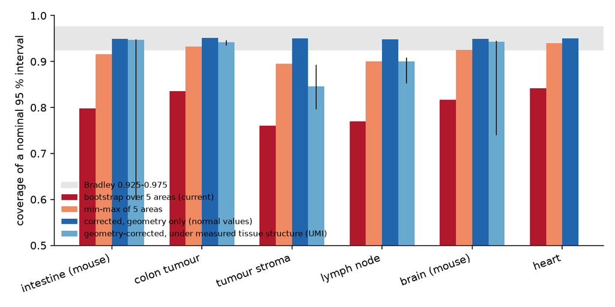

Copertura di un intervallo dichiarato al 95 %, per tessuto: metodo di oggi (bootstrap sulla media di 5 aree), minimo-massimo, correzione con la sola geometria, e la stessa correzione sotto la struttura del tessuto misurata (campo UMI, banda bootstrap sulle aree).

*Cosa guardare*: le barre rosse stanno tutte sotto la fascia grigia (criterio di Bradley); la correzione geometrica ci entra ovunque con valori normali, ma sotto la struttura misurata esce nello stroma e nel linfonodo.

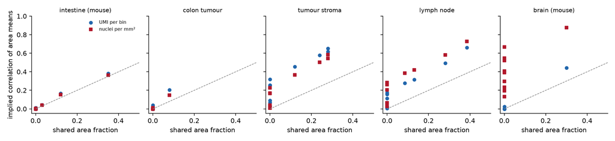

Correlazione fra le medie di due aree implicita nella struttura del tessuto misurata dentro le aree, contro la quota di area in comune; un punto per coppia di aree, due campi. Linea tratteggiata: correlazione uguale alla quota in comune.

*Cosa guardare*: nell’intestino e nel tumore i punti stanno sulla diagonale (basta la geometria); nello stroma e nel linfonodo stanno molto sopra.

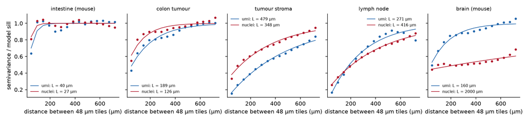

Semivariogrammi delle tessere di 48 µm dentro le aree (punti) e modello esponenziale con pepita (linee), normalizzati alla soglia del modello.

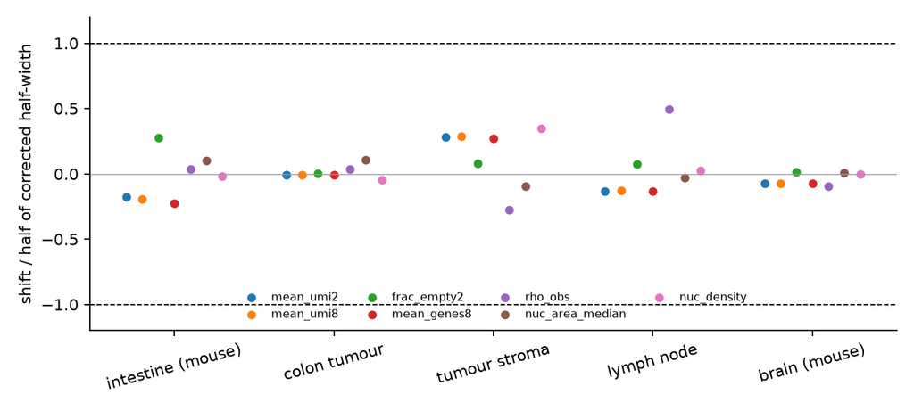

Previsione 3: spostamento del valore del tessuto contando ogni nucleo e ogni bin una volta, in unità di metà della semi-ampiezza corretta; le linee tratteggiate sono la soglia.

# Controprova e analisi post hoc

- **PH-1, fino a quale asimmetria regge la correzione** (`R7_PH1_cv.csv`, `R7_cv_factor.csv`): con valori lognormali la copertura dell’allargamento calibrato resta dentro Bradley fino a un CV fra aree di circa 0.45 (0.929 con aree indipendenti, 0.926 nello stroma), poi scende (0.912 a CV 0.62, 0.868 a CV 1). Per CV sopra 0.45 serve un fattore in più (1.17 a CV 0.45, 1.34 a 0.62, 1.75 a 1). I riferimenti con CV fra aree sopra 0.45 sono 24 componenti su 237 con valori per area: frazioni di bin vuoti, tipi rari, contatti nelle maschere, sfocatura nel tessuto (`R7_Mc_refs.csv`, colonne `lo_cv`, `hi_cv`).
- **PH-2, sensibilità sul cervello**: con i fattori geometrici del cervello cambiano 3 righe di R4-S2.4 (taglia per tipo, aree nucleari per tipo), 209 righe di S1.5-S1.6 e due regole (S1.5c regola 1, S1.5e quote); i bersagli del confronto finale nel cervello sono per bin e cambiano del 3 %.

# Revisione avversariale

- **Revisore numerico** (ricalcolo indipendente senza `R7_common.py`): tornano quote di zona comune, copertura del metodo di oggi con B = 2000 casuali (|z| ≤ 1.46), κ sulla geometria (scarto massimo 0.026), P-1 con aree indipendenti, semivariogramma del linfonodo (L 271.44 µm), P-3 nello stroma e nel linfonodo (≤ 1.6e-16). Due κ dalla struttura misurata oltre la tolleranza di 0.03: chiusi con C-1. Osservazioni registrate come deviazioni (DV-2, DV-3, DV-6) e figura dei valori di E-0.
- **Revisore del codice**: formule, enumerazione esatta, coordinate, semivariogramma e correlazione implicita corretti; flussi casuali di calibrazione e valutazione separati. Tre errori: banda di P-2 (C-2), due κ diversi (C-1), κ_range senza zone comuni non 1 (C-3). Nove deviazioni da dichiarare (sezione seguente).
- **Revisore delle conseguenze, primo giro**: le conseguenze dichiarate si riproducono, ma due errori di applicazione: il lato simulato allargato con il κ del tessuto vero (C-4) e κ delle finestre sull’intervallo a due stadi (C-5); contabilità (C-6).
- **Revisore delle conseguenze, secondo giro** (dopo le correzioni, codice proprio su 5 395 righe di S1.5-S1.6, campione di 40 righe cambiate nelle tre tabelle): 8 esiti su 8 confermati; nel campione, 38 righe su 40 usano costruzione, lato e fattore giusti; le altre 2 (CP-1 ER-K2 nello stroma, una riga di componente, e l’esito aggregato di CP-2) mostrano un κ diverso da quello applicato alle loro componenti; il revisore le ha ispezionate e gli esiti non cambiano. Fragilità: ogni cambio di regola del livello cellulare dipende da una riga o da un pareggio; quello del modello di taglia di S1.5d passa per 8.0e-5, entro l’errore Monte Carlo di κ delle finestre (0.6 errori). Varianti ragionevoli (fattori geometrici nel cervello, κ del tessuto sul lato simulato, prova di stress anche sui margini minimo-massimo) riportano indietro quasi tutti i cambi. Discrepanze: (D-1) l’intervallo a uno stadio delle finestre restringe il margine nello stroma (0.117-0.216 contro 0.083-0.283), sotto il limite binomiale di 60 nuclei (± 0.098); (D-2) medie su 4 aree simulate con il fattore per 5 (nessun verdetto cambia); (D-3) margini su 3 aree nel cervello con κ_range per 5 (effetto non quantificato).
- Rapporti: `R7_review_num.md`, `R7_review_code.md`, `R7_review_cons.md`, `R7_review_cons2.md` (artifact della sessione; script dei revisori su `/tmp/r7rev_*` del server).

## Correzioni dopo la revisione

La revisione (sezione seguente) ha trovato errori di applicazione; sono corretti così, prima dei verdetti finali. Le versioni precedenti restano nei commit `b63c6eb` e nella storia di `results/R7/`.

- **C-1, un solo κ ricalibrato.** P-1, P-2 e la figura 1 usavano la calibrazione a un seme (20 000 repliche), il resto la media di 5 semi; ora un’unica tabella da 10⁶ repliche per matrice (errore Monte Carlo di κ 0.002-0.006), `results/R7/coverage/R7_kappa_v3_all.csv`. Le due discrepanze del revisore numerico (stroma, campo UMI: 3.188 contro 3.153; linfonodo, campo nuclei: 2.960 contro 2.992) si chiudono: 3.193 e 2.966.
- **C-2, banda bootstrap di P-2.** Le 2 000 repliche bootstrap riusavano le stesse 4 000 estrazioni normali, che spostavano tutta la banda del loro errore Monte Carlo; rifatta con 20 000 estrazioni comuni (`tools/R7_cp1_v2.py`, `results/R7/cp1_v2/`). Cambiano due esiti: stroma, campo nuclei, da smentita a indeterminata; cervello, campo nuclei, da indeterminata a smentita.
- **C-3, κ_range esatto senza zone comuni.** Numeratore e denominatore erano simulati con estrazioni diverse (cuore 0.9996); ora con le stesse estrazioni, e vale 1 esatto nel cuore.
- **C-4, il fattore dipende da come è costruito l’intervallo e da chi viene.** κ era calibrato per il bootstrap percentile sulle aree vere; per un intervallo «stima ± 2 errori standard» serve κ_SE (5 aree indipendenti: 1.3905, atteso t(4)/2 = 1.3882), e le aree simulate (una simulazione e un seme per area, nessuna cellula condivisa) hanno solo il problema delle poche unità (riga `sim_5`). Prima il lato simulato riceveva il κ del tessuto vero (fino a 3.0).
- **C-5, finestre contate a mano: κ sull’intervallo a uno stadio.** κ per 4 finestre è calibrato sul bootstrap a uno stadio; la premessa di R-3 (due stadi circa uguale a uno stadio) vale per R4 (rapporto 0.86-1.23, misura M-f) ma non per le finestre (due stadi 1.1-4 volte più largo). L’intervallo a due stadi, dove è il solo che esiste, resta com’è ed è segnalato.
- **C-6, contabilità.** Etichette delle transizioni uniformi; S2.4 P-5 nel cuore (una sola tessera) resta non valutabile; R2c CP-5 (2 finestre) non si corregge.

Tabella finale dei fattori: `results/R7/coverage/R7_kappa_final_v4.csv` (`tools/R7_kappa_final_v4.py`).

## Deviazioni dichiarate

- **DV-1**: κ da una calibrazione a 10⁶ repliche invece di 20 000 (solo precisione).
- **DV-2**: R-2 letta come «se una coppia qualsiasi supera 0.05»: matrici specifiche per bin e per nuclei in tutti i tessuti (effetto +1.4 % a +2.3 % nell’intestino e nel cervello; letta per tessuto varrebbe solo per i nuclei dello stroma).
- **DV-3**: F_nuc con i nuclei Cellpose-RGB (il segmentatore dei riferimenti attivi) invece di Cellpose-HED scritto in M-1.
- **DV-4**: dove scatta R-1, il fattore «altre quantità» è il maggiore dei due campi, e anche κ_range viene dalla struttura misurata.
- **DV-5**: in P-3 il limite delle due quantità dei nuclei viene da un bootstrap sulle aree (seme dello step), non da una riga di riferimento; con i fattori geometrici il rapporto massimo sarebbe 0.645, ancora confermata.
- **DV-6**: pesi del semivariogramma con il γ del modello (Cressie) invece del γ empirico scritto; ρ̄ cambia al più di 0.007.
- **DV-7**: M-f confronta la mediana delle cellule riunite con la media delle mediane per area (statistiche diverse).
- **DV-8**: nel riesame (M-5) le validazioni lasciando fuori un’area e gli intervalli su tessere dentro una sezione restano senza correzione (regola); i confronti appaiati simulato meno vero prendono il fattore del tessuto vero (scelta conservativa); 84 righe con medie su 4 aree simulate e i margini su 3 aree nel cervello hanno il fattore per 5 (D-2, D-3).
- **DV-9**: la classificazione delle componenti (costruzione, lato, tipo) nelle tabelle del riesame è dei sotto-agenti, controllata dal secondo revisore su un campione di 40 righe.

# Cosa è girato

- Ramo `step2-visium-grid`; commit dei cancelli `c4832c2`, dell’ok `e19fd2a`, del calcolo `b63c6eb`, delle correzioni `31ea40d`; commit di chiusura nel file dello step.
- Server lesexp-server, Python del progetto (`.venv`), al massimo 6 processi a un thread; il server era condiviso con un altro utente (carico fino a 521, temperatura 59-71 °C).
- Semi: 20261108 per tutte le simulazioni e i bootstrap di R7 (flussi separati per caso); semi di R4 per la riproduzione G-3.
- md5 dei 248 file letti identici prima e dopo (`results/R7/R7_md5_before.txt`, `R7_md5_after.txt`).
- Script: `tools/R7_*.py`, `tools/R7_M5/` (riesame dei verdetti e riferimenti corretti, scritti dai sotto-agenti); tabelle in `results/R7/`.

## Esplorazioni prima della pre-registrazione

- **E-0, geometria** (`results/R2/R2_rois_checked.csv`, ricalcolo in chat). Quota dell’area in comune fra due aree dello stesso tessuto: intestino r3-r5 0.345, r2-r4 0.122, r3-r4 0.028; tumore r4-r5 0.077; stroma r1-r2 0.278, r2-r5 0.278, r3-r5 0.240, r3-r4 0.120; linfonodo f2-p2 0.384, p2-p3 0.278, f2-p1 0.131, f2-p3 0.082, f1-f2 0.002; cervello r2-r5 0.301; cuore nessuna. Le 24 finestre di 100 µm contate a mano (R2b) non si sovrappongono fra loro; 4 cadono in zone comuni a più aree (intestino w3, stroma w4, linfonodo w3 e w4).
- **E-1, la stessa coppia di aree spostata nel tessuto intorno** (`tools/R7_explore_E1.py`, `results/R7/explore/R7_E1_*.csv`). Campo: UMI medi per bin di 8 µm di Space Ranger. Per ogni coppia di aree di R2 si sposta la coppia, con lo stesso scarto, su una griglia di 50 µm nell’unione delle aree dilatata di 1 mm, e si correlano le due medie. Risultato: correlazioni alte anche fra aree che non si toccano (tumore 0.35-0.82, linfonodo fino a 0.86, cuore fino a 0.73) e negative fra aree lontane (intestino r1-r5 −0.60, cervello r1-r4 −0.69); la deviazione standard fra le posizioni della griglia è da 1.2 (cuore) a 3.3 volte (linfonodo) quella fra le 5 aree di R2. Lettura: il tessuto intorno mescola compartimenti, le aree di R2 sono state scelte dentro uno. La stima non si usa per correggere gli intervalli; al suo posto, la correlazione dentro le aree (CP-1).
- **E-2, copertura dell’intervallo usato da R4 in poi** (`tools/R7_explore_E2.py`, `results/R7/explore/R7_E2_coverage.csv`; valori per area normali, 4 000 repliche, errore Monte Carlo circa 0.006). Bootstrap percentile della media di 5 aree, enumerazione esatta: 0.842 con aree indipendenti; con la correlazione uguale alla quota in comune 0.797 intestino, 0.835 tumore, 0.759 stroma, 0.770 linfonodo, 0.816 cervello, 0.846 cuore. Intervallo fra minimo e massimo delle 5 aree, come intervallo della media: 0.936 indipendenti, da 0.890 (stroma) a 0.939 (cuore).
- **Inventario** (sotto-agente, sola lettura, `results/R7/inventory/`): 213 righe di `BIO_REFERENCES.md` su 461 hanno l’area di R2 come unità dell’incertezza, 184 non superate (155 nei 5 tessuti con zone comuni); per tipo: 93 bootstrap percentile (R4, R6, S2.0, S2.2), 64 minimo-massimo, 27 validazioni lasciando fuori un’area (S1.4, S1.5d). 18 righe hanno le finestre come unità. Limiti dichiarati dal sotto-agente: uso come margine e tabella dei verdetti da ricerca per parole chiave; file per area verificati numericamente su 14 righe dell’intestino; 10 righe senza file per area trovato.

Queste esplorazioni fissano le domande; nessuna previsione qui sotto riguarda una quantità già calcolata.

# Appendice

## Riesame dei verdetti per step

| step | rows | affected | changed_three | rule_or_other_changes | confermata->indeterminata | smentita->indeterminata | smentita->confermata | indeterminata->confermata | indeterminata->smentita | confermata->smentita |
| --- | --- | --- | --- | --- | --- | --- | --- | --- | --- | --- |
| R2b | 52 | 0 | 0 | 0 | 0 | 0 | 0 | 0 | 0 | 0 |
| R2c | 58 | 18 | 4 | 0 | 0 | 0 | 4 | 0 | 0 | 0 |
| R3 | 55 | 0 | 0 | 0 | 0 | 0 | 0 | 0 | 0 | 0 |
| R3b | 24 | 8 | 1 | 0 | 1 | 0 | 0 | 0 | 0 | 0 |
| R4 | 36 | 30 | 5 | 0 | 2 | 3 | 0 | 0 | 0 | 0 |
| R5 | 75 | 24 | 2 | 0 | 2 | 0 | 0 | 0 | 0 | 0 |
| R6 | 38 | 38 | 11 | 0 | 6 | 5 | 0 | 0 | 0 | 0 |
| S1.3 | 195 | 0 | 0 | 0 | 0 | 0 | 0 | 0 | 0 | 0 |
| S1.3b | 61 | 0 | 0 | 0 | 0 | 0 | 0 | 0 | 0 | 0 |
| S1.3c | 209 | 0 | 0 | 0 | 0 | 0 | 0 | 0 | 0 | 0 |
| S1.3d | 48 | 0 | 0 | 0 | 0 | 0 | 0 | 0 | 0 | 0 |
| S1.4 | 92 | 24 | 0 | 0 | 0 | 0 | 0 | 0 | 0 | 0 |
| S1.4b | 104 | 52 | 0 | 0 | 0 | 0 | 0 | 0 | 0 | 0 |
| S1.4c | 264 | 221 | 0 | 1 | 0 | 0 | 0 | 0 | 0 | 0 |
| S1.4d | 46 | 27 | 1 | 0 | 0 | 0 | 0 | 1 | 0 | 0 |
| S1.4e | 96 | 70 | 8 | 7 | 0 | 2 | 2 | 3 | 1 | 0 |
| S1.4f | 192 | 167 | 21 | 7 | 0 | 4 | 5 | 8 | 4 | 0 |
| S1.5 | 146 | 98 | 16 | 0 | 4 | 6 | 3 | 2 | 1 | 0 |
| S1.5b | 167 | 167 | 11 | 1 | 0 | 4 | 5 | 2 | 0 | 0 |
| S1.5c | 772 | 772 | 91 | 2 | 15 | 26 | 23 | 21 | 6 | 0 |
| S1.5d | 1999 | 1992 | 222 | 1 | 44 | 59 | 69 | 45 | 5 | 0 |
| S1.5e | 1295 | 1260 | 130 | 1 | 32 | 32 | 24 | 40 | 2 | 0 |
| S1.6 | 1440 | 1434 | 156 | 0 | 42 | 46 | 40 | 25 | 3 | 0 |
| S1.6b | 1 | 0 | 0 | 0 | 0 | 0 | 0 | 0 | 0 | 0 |
| S2.0 | 37 | 9 | 0 | 0 | 0 | 0 | 0 | 0 | 0 | 0 |
| S2.1 | 25 | 0 | 0 | 0 | 0 | 0 | 0 | 0 | 0 | 0 |
| S2.2 | 56 | 32 | 1 | 0 | 1 | 0 | 0 | 0 | 0 | 0 |
| S2.3 | 134 | 114 | 19 | 0 | 9 | 10 | 0 | 0 | 0 | 0 |
| S2.4 | 135 | 67 | 10 | 0 | 10 | 0 | 0 | 0 | 0 | 0 |
| TOTAL | 7852 | 6624 | 709 | 20 | 168 | 197 | 175 | 147 | 22 | 0 |

## Cambi di regole e controprove

| step | prediction_id | transition | verdict_new_stress | verdict_geom_A5 |
| --- | --- | --- | --- | --- |
| S1.4c | CP-2 S1 | exceeds (>=3/5 ROI above max of yardstick)->does not exceed | does not exceed |  |
| S1.4e | Regola N | winner K2->ET | K2 (scores {‘K2’: 6, ‘ER’: 6, ‘ET’: 7}) |  |
| S1.4e | CP-1 ET-K2 | sotto zero->non sotto zero | non sotto zero |  |
| S1.4e | CP-1 ER-K2 | sotto zero->non sotto zero | non sotto zero |  |
| S1.4e | CP-1 con le non giudicabili ER-K2 | sotto zero->non sotto zero | non sotto zero |  |
| S1.4e | CP-1 con le non giudicabili ET-K2 | sotto zero->non sotto zero | non sotto zero |  |
| S1.4e | CP-1 con le non giudicabili ER-K2 | sotto zero->non sotto zero | non sotto zero |  |
| S1.4e | CP-1 con le non giudicabili (esito) | ET part met, ER part not->superata | superata |  |
| S1.4f | Regola O cell V0 nn6-8 | outside->inside | inside |  |
| S1.4f | CP-1 EP-K2 | sotto zero->non sotto zero | non sotto zero |  |
| S1.4f | CP-1 ET-K2 | sotto zero->non sotto zero | non sotto zero |  |
| S1.4f | S-1 EP-K2 | sotto zero->non sotto zero | non sotto zero |  |
| S1.4f | S-1 ET-K2 | sotto zero->non sotto zero | non sotto zero |  |
| S1.4f | S-1 EP-K2 | sotto zero->non sotto zero | non sotto zero |  |
| S1.4f | CP-2 (esito) | superata (6/8)->superata (5/8) | superata (5/8) |  |
| S1.5b | RULE choice 2 | recentred->group | group | group |
| S1.5c | RULE 1 | N->C | N | N |
| S1.5c | RULE 2 | N-a->C-a | N-a | N-a |
| S1.5d | RULE C | gaussian->empirical | gaussian | empirical |
| S1.5e | RULE Q | senza quote->con quote | con quote | senza quote |

## Bersagli del confronto finale: intervalli vecchi e corretti

| id | archetype | metric | vecchio | corretto | kappa |
| --- | --- | --- | --- | --- | --- |
| B-270 | A1 | mean UMI per 2 um bin in tissue | 27.14 [25.8, 28.49] | [24.64, 29.64] | 1.857 |
| B-270 | A1 | fraction of empty 2 um bins in tissue | 0.01695 [0.0142, 0.0197] | [0.01185, 0.02206] | 1.857 |
| B-271 | A1 | mean UMI per 8 um bin in tissue | 424.8 [405.1, 444.4] | [388.3, 461.2] | 1.857 |
| B-271 | A1 | fraction of empty 8 um bins in tissue | 0 [0, 0] | [0, 0] | 1.857 |
| B-272 | A1 | genes detected per 2 um bin | 25.2 [24.03, 26.38] | [23.02, 27.39] | 1.857 |
| B-272 | A1 | genes detected per 8 um bin | 323.8 [310.6, 336.5] | [299.4, 347.4] | 1.857 |
| B-274 | A1 | nucleus/ring UMI-per-bin ratio, cell-weighted, divided by the 20 um shifted-mask ratio (Step 2 reference) | 0.9856 [0.9747, 0.9966] | [0.9653, 1.006] | 1.857 |
| B-280 | A2 | mean UMI per 2 um bin in tissue | 45.46 [38.48, 53.08] | [33.9, 58.07] | 1.655 |
| B-280 | A2 | fraction of empty 2 um bins in tissue | 0.01072 [0.006141, 0.01728] | [0.003137, 0.02158] | 1.655 |
| B-281 | A2 | mean UMI per 8 um bin in tissue | 719.5 [611.5, 838.7] | [540.8, 916.8] | 1.655 |
| B-281 | A2 | fraction of empty 8 um bins in tissue | 0 [0, 0] | [0, 0] | 1.655 |
| B-282 | A2 | genes detected per 2 um bin | 43.32 [36.68, 50.69] | [32.33, 55.52] | 1.655 |
| B-282 | A2 | genes detected per 8 um bin | 582 [501.6, 675.9] | [448.9, 737.4] | 1.655 |
| B-284 | A2 | nucleus/ring UMI-per-bin ratio, cell-weighted, divided by the 20 um shifted-mask ratio (Step 2 reference) | 0.847 [0.8277, 0.8662] | [0.8151, 0.8789] | 1.655 |
| B-290 | A3 | mean UMI per 2 um bin in tissue | 19.53 [16.24, 21.88] | [9.016, 27.02] | 3.193 |
| B-290 | A3 | fraction of empty 2 um bins in tissue | 0.02209 [0.01609, 0.02809] | [0.002954, 0.04124] | 3.193 |
| B-291 | A3 | mean UMI per 8 um bin in tissue | 312.4 [259.7, 349.6] | [144.3, 431.3] | 3.193 |
| B-291 | A3 | fraction of empty 8 um bins in tissue | 0.0005754 [0, 0.001726] | [-0.001262, 0.004249] | 3.193 |
| B-292 | A3 | genes detected per 2 um bin | 18.57 [15.39, 20.83] | [8.416, 25.79] | 3.193 |
| B-292 | A3 | genes detected per 8 um bin | 259.1 [216, 291.4] | [121.4, 362.1] | 3.193 |
| B-294 | A3 | nucleus/ring UMI-per-bin ratio, cell-weighted, divided by the 20 um shifted-mask ratio (Step 2 reference) | 0.8918 [0.8538, 0.9279] | [0.7705, 1.007] | 3.193 |
| B-302 | A4 | mean UMI per 2 um bin in tissue | 11.4 [10.4, 12.12] | [8.831, 13.26] | 2.571 |
| B-302 | A4 | fraction of empty 2 um bins in tissue | 0.01199 [0.00526, 0.02103] | [-0.005312, 0.03524] | 2.571 |
| B-303 | A4 | mean UMI per 8 um bin in tissue | 182.4 [166.4, 193.9] | [141.1, 211.9] | 2.571 |
| B-303 | A4 | fraction of empty 8 um bins in tissue | 0.0004096 [0, 0.001229] | [-0.0006435, 0.002516] | 2.571 |
| B-304 | A4 | genes detected per 2 um bin | 10.99 [10.07, 11.7] | [8.633, 12.82] | 2.571 |
| B-304 | A4 | genes detected per 8 um bin | 163.1 [150.5, 173.2] | [130.8, 189] | 2.571 |
| B-306 | A4 | nucleus/ring UMI-per-bin ratio, cell-weighted, divided by the 20 um shifted-mask ratio (Step 2 reference) | 0.788 [0.7717, 0.8034] | [0.746, 0.8276] | 2.571 |
| B-315 | A5 | mean UMI per 2 um bin in tissue | 41.79 [39.33, 44.25] | [37.32, 46.27] | 1.818 |
| B-315 | A5 | fraction of empty 2 um bins in tissue | 0.0004652 [0.000145, 0.0008188] | [-0.000117, 0.001108] | 1.818 |
| B-316 | A5 | mean UMI per 8 um bin in tissue | 667.4 [628.2, 706.7] | [596.1, 738.8] | 1.818 |
| B-316 | A5 | fraction of empty 8 um bins in tissue | 0 [0, 0] | [0, 0] | 1.818 |
| B-317 | A5 | genes detected per 2 um bin | 40.75 [38.48, 43.13] | [36.63, 45.09] | 1.818 |
| B-317 | A5 | genes detected per 8 um bin | 541.8 [510.4, 573.2] | [484.7, 598.9] | 1.818 |
| B-319 | A5 | nucleus/ring UMI-per-bin ratio, cell-weighted, divided by the 20 um shifted-mask ratio (Step 2 reference) | 1.383 [1.362, 1.402] | [1.344, 1.417] | 1.818 |
| B-327 | A6 | mean UMI per 2 um bin in tissue | 3.425 [2.561, 4.289] | [2.021, 4.829] | 1.624 |
| B-327 | A6 | fraction of empty 2 um bins in tissue | 0.1453 [0.0985, 0.1823] | [0.06928, 0.2055] | 1.624 |
| B-328 | A6 | mean UMI per 8 um bin in tissue | 54.78 [41.75, 68.59] | [33.61, 77.21] | 1.624 |
| B-328 | A6 | fraction of empty 8 um bins in tissue | 0.002331 [0.0004226, 0.005547] | [-0.0007686, 0.007555] | 1.624 |
| B-329 | A6 | genes detected per 2 um bin | 3.328 [2.502, 4.154] | [1.987, 4.67] | 1.624 |
| B-329 | A6 | genes detected per 8 um bin | 44.57 [34.27, 54.87] | [27.84, 61.31] | 1.624 |
| B-331 | A6 | nucleus/ring UMI-per-bin ratio, cell-weighted, divided by the 20 um shifted-mask ratio (Step 2 reference) | 1.784 [1.64, 1.927] | [1.55, 2.017] | 1.624 |

## Attese pre-registrate (testo integrale)

Commit dei cancelli: `c4832c2`. Ok di Luca sulle previsioni: 2026-11-08, «Ok, come proposte (Recommended)» (chat), soglie comprese (criterio di Bradley per le coperture; metà della semi-ampiezza corretta per P-3). Commit: questo commit, «R7: ok di Luca sulle previsioni (2026-11-08)».

### Metodi

- **M-1, geometria.** Tre matrici per tessuto: quota di area in comune fra i quadrati (F_box); quota dei bin di 2 µm in tessuto condivisi (F_bin, dai file per area di R4, posizione globale = posizione nell’area + angolo dell’area, in pixel interi); quota dei nuclei condivisi (F_nuc, nuclei Cellpose-HED di R2 tenuti, scala 1, centroide globale). Correlazione per coppia n_ij / √(n_i n_j). F_box è la matrice primaria; F_bin e F_nuc servono a controllarla (regola R-2).
- **M-2, pezzi disgiunti** (l’alternativa indicata nel step sulle aree sovrapposte prima di S2.5 (DEC-048)). Ogni punto dell’unione delle 5 aree va all’area che lo contiene con il centro più vicino (a parità, l’area con l’indice più basso). Ogni nucleo e ogni bin conta una volta. Nel cuore i pezzi coincidono con le aree.
- **M-3, simulazione di copertura.** Valori per area x = μ + σ·z, z normale con matrice di correlazione data, 5 aree (4 per le finestre, indipendenti perché disgiunte). Metodo di oggi: bootstrap percentile della media con enumerazione esatta delle 5⁵ estrazioni (B infinito; equivalenza con `R4_common.boot_one_stage` a B = 2000 nel cancello G-1). Candidati: **C-a**, allargamento calibrato: le due semi-ampiezze dell’intervallo registrato (stima − inferiore, superiore − stima) moltiplicate per κ, il fattore che porta la copertura a 0.95 con la correlazione F_box del tessuto; **C-b**, intervallo t con l’effetto della correlazione: x̄ ± t(n−1; 0.975) · s/√n · k, con k = √((1 + (n−1)ρ̄)/(1 − ρ̄)), ρ̄ media delle correlazioni fuori diagonale. Per gli intervalli minimo-massimo (descrittivi: «fra aree vere») si corregge solo la zona comune: κ_range = rapporto fra l’ampiezza attesa di 5 aree indipendenti e quella con F_box. Repliche 20 000 per ogni caso (errore Monte Carlo circa 0.0015 a 0.95); seme 20261108.
- **M-4, correlazione dentro le aree** (base di CP-1). Campi: UMI medi per bin di 2 µm in tessuto e nuclei per mm² di tessuto, su tessere di 48 µm di una griglia globale, solo nell’unione delle 5 aree (tessere con almeno metà dei bin in tessuto; nuclei presi dal pezzo disgiunto di ciascuna area, così nessuno conta due volte). Semivariogramma empirico fra 48 e 720 µm in 15 classi, coppie di tessere della stessa area; modello γ(h) = c0 + c1 (1 − exp(−h/L)) adattato per minimi quadrati pesati (pesi N_h/γ(h)²), L fra 10 e 2 000 µm. Correlazione implicita fra le medie di due aree: media delle covarianze del modello fra le tessere delle due aree, normalizzata. Incertezza: bootstrap sulle 5 aree (si ricampionano i semivariogrammi per area e si riadatta), B = 2000, seme 20261108, 4 000 repliche di copertura per bootstrap.
- **M-5, riesame dei verdetti passati.** Per ogni verdetto degli step da R2 a S2.4 nelle tabelle dei verdetti o delle previsioni, se la stima o l’intervallo di rilevanza viene da aree o finestre: stesso giudizio con l’intervallo corretto dalla regola R-1 (κ sul lato per area, κ_range sui margini minimo-massimo), con la funzione dei verdetti di R4 (`R4_common.verdict`). Tabella delle transizioni per step e tessuto. Ogni transizione che tocca una scelta oggi in uso (preset, modello, riferimento adottato) è un dubbio da chiudere.

### Regole di decisione dei dati (scritte prima del calcolo)

- **R-1, la correzione** (BL-186, decisa dai dati per scelta di Luca). Si adotta, fra C-a e C-b, quella con la copertura dentro l’intervallo di Bradley (0.925-0.975) nel maggior numero di celle tessuto × scenario, sugli scenari di P-1 (normale, lognormale, t con 3 gradi di libertà); a parità, C-a (si applica agli intervalli registrati senza i valori per area e ne conserva l’asimmetria). Se P-2 è smentita in un tessuto, in quel tessuto κ si calibra sulla correlazione implicita di M-4 (stima puntuale) invece che su F_box.
- **R-2, quale matrice di zone comuni.** Se F_bin e F_nuc differiscono da F_box di più di 0.05 in una coppia, per le quantità per bin e per nucleo si usa la matrice specifica; altrimenti F_box per tutte.
- **R-3, due stadi.** Per le righe con bootstrap a due stadi (aree, poi cellule) si usa il κ a uno stadio; il rapporto fra le semi-ampiezze a due e a uno stadio si misura su una riga di R4 per tessuto (misura M-f).

### Cancelli (al massimo 5)

| id | controllo | tolleranza | comando |
| --- | --- | --- | --- |
| G-1 | batteria `tools/R7_test.py`: quote di zona comune su quadrati sintetici noti; formula di k contro simulazione bruta di Var(x̄) ed E[s²]; intervallo t con aree normali indipendenti copre 0.950; enumera… | numerica (copertura entro 3 errori Monte Carlo) | `.venv/bin/python tools/R7_test.py` |
| G-2 | geometria e pezzi sui dati veri: F_box uguale ai valori di BL-215 ed E-0 entro 0.005; cuore senza zone comuni; ogni nucleo e ogni bin in un solo pezzo; nel cuore valori sui pezzi identici bit per bit … | 0.005; identità | `tools/R7_run.sh G2` |
| G-3 | riproduzione: le quantità per area di R4 ricalcolate dai file per area senza pezzi uguali a `results/R4/R4_roi.csv`; gli intervalli registrati in `results/R4/R4_refs.csv` (bootstrap a uno stadio) rica… | 1e-9 relativo | `tools/R7_run.sh G3` |
| G-4 | integrità: md5 prima e dopo di tutto ciò che si legge (aree, nuclei, file per area di R4, maschere, tabelle dei verdetti, `BIO_REFERENCES.md`) | identità | `tools/R7_md5.sh before/after` |
| G-5 | revisione avversariale: sotto-agenti indipendenti ricalcolano dal codice e dai dati κ e κ_range per tessuto, le coperture di P-1 e P-2, gli scarti di P-3 e le transizioni di M-5 | numerica | report, sezione revisione |

### Previsioni

Unità indipendente per l’incertezza: replica della simulazione (P-1); area di R2, con bootstrap sulle 5 aree (P-2); nessuna per P-3 (scarto calcolato esattamente sugli stessi dati). B = 2000; seme = 20261108. Intervallo di rilevanza per le coperture: criterio liberale di Bradley, 0.925-0.975, scelto da Luca il 2026-11-08 (regola 3 del protocollo: non è un valore biologico; è la convenzione già usata in MMM).

| id | quantità | archetipo | atteso | intervallo di rilevanza | fonte dell’intervallo | 2 errori standard tipici |
| --- | --- | --- | --- | --- | --- | --- |
| P-1 | copertura dell’intervallo corretto con R-1 quando i valori per area non sono normali: lognormali con CV alto (90° percentile dei CV fra aree delle quantità di `R4_roi.csv`) e t con 3 gradi di libertà … | tutti, A1-A6 | dentro l’intervallo in 6 tessuti su 6 per entrambi gli scenari | 0.925-0.975 | Bradley | 0.003 (Monte Carlo) |
| P-2 (controprova CP-1) | copertura dell’intervallo corretto con κ calibrato su F_box quando le aree hanno la correlazione implicita nella struttura del tessuto misurata dentro le aree (M-4), per UMI per bin e per nuclei | A1-A5 (nel cuore nessuna zona comune: la correzione per le zone comuni vale 1) | dentro l’intervallo, per entrambi i campi, in 5 tessuti su 5 | 0.925-0.975 | Bradley | non noto prima del calcolo; se l’intervallo bootstrap è più largo di metà dell’intervallo di rilevanza, l’esito sarà indeterminato |
| P-3 (controprova CP-2) | scarto del valore del tessuto quando ogni nucleo e ogni bin conta una volta (pezzi disgiunti) invece che nelle aree: UMI per bin a 2 e 8 µm, frazione di bin vuoti a 2 µm, geni per bin a 8 µm, rapporto… | A1-A5 (nel cuore è 0 per costruzione, cancello G-2) | dentro l’intervallo per tutte le 7 quantità in 5 tessuti su 5 | ± metà della semi-ampiezza dell’intervallo corretto della stessa quantità (circa 1 errore standard) | variabilità fra aree misurata sui dati veri (regola 2 del protocollo), fattore 0.5 scelto da Luca il 2026-11-08 | nessuno: lo scarto è esatto per questi dati |

### Controprova

- **CP-1 = P-2.** Se la struttura del tessuto dentro le aree rendesse le aree sovrapposte molto più correlate della sola quota in comune, la correzione calibrata sulla geometria sarebbe troppo piccola e la copertura vera scenderebbe sotto 0.925. Allora R-1 calibra κ su quella correlazione.
- **CP-2 = P-3.** La correzione cambia solo gli intervalli. Se contare due volte le zone comuni spostasse il valore stesso dei riferimenti, andrebbero rifatti i valori, non solo allargati gli intervalli.
- **CP-3, cuore (controllo negativo per le zone comuni).** Senza zone comuni la parte di correzione dovuta alle zone comuni vale esattamente 1, e i pezzi coincidono con le aree (cancello G-2).

### Misure (senza intervallo; servono alle decisioni)

- M-a: κ, κ_range e k per tessuto e per numero di unità (5 aree, 4 finestre); copertura del metodo di oggi a 20 000 repliche.
- M-b: transizioni dei verdetti passati (M-5), per step, tessuto e tipo di transizione.
- M-c: riferimenti corretti per il confronto finale (righe attive con unità area o finestra): valore, intervallo registrato, intervallo corretto.
- M-d: quota dei nuclei dell’area tenuta fuori che stanno anche nelle aree di stima, per le validazioni lasciando fuori un’area (S1.4, S1.5c, S1.5d, S2.2).
- M-e: deviazione standard fra pezzi disgiunti contro quella fra aree, per le 7 quantità di P-3.
- M-f: rapporto fra le semi-ampiezze del bootstrap a due e a uno stadio, una riga di R4 per tessuto.

## Da dove vengono i numeri del riassunto

| frase del riassunto | fonte | valore letto |
| --- | --- | --- |
| «fra 76 e 84 volte su 100» | `results/R7/coverage/R7_kappa.csv`, `cover_now` | 0.760 (stroma) … 0.842 (cuore); 5 aree indipendenti 0.837 |
| «76 su 100 nello stroma, 77 nel linfonodo» | idem | 0.7603; 0.7696 |
| «fra 89 e 94 su 100» (minimo-massimo) | idem, `cover_minmax` | 0.8946 … 0.9395 |
| «1,6-1,9 volte»; «2,6-3,2 volte» | `results/R7/coverage/R7_kappa_final_v4.csv` | cuore 1.624-1.627, tumore 1.655-1.666, intestino 1.837-1.857; stroma 2.817-3.193, linfonodo 2.571-2.966 |
| «strutture di 270-480 µm» | `results/R7/cp1_v2/R7_P2.csv`, `L_um` | stroma 479 e 348; linfonodo 271 e 416 |
| «1,8 per i trascritti, 3,9 per i nuclei» (cervello) | `R7_kappa_final_v4.csv` | 1.818; 3.865 |
| «24 intervalli su circa 240» | `results/R7/Mc/R7_Mc_refs.csv`, `cv_between_areas` | 24 con CV > 0.45 su 237 con valori per area |
| «al più del 7 %», «meno di metà» | `results/R7/pieces/R7_P3.csv` | rel_shift massimo 0.0734 (linfonodo, frac_empty2); shift_over_bound massimo 0.496 |
| «circa 7 900 verdetti di 29 step ne cambiano 709» | `results/R7/report/R7_transitions_by_step.csv`, riga TOTAL | 7 852 righe; 709 cambi fra i tre esiti |
| «circa metà … non decisi; poco meno di metà … confermati»; «22» | idem | 168 + 197 = 365; 175 + 147 = 322; indeterminata → smentita 22; confermata → smentita 0 |
| «quattro regole … pareggio o un punto»; «163 conferme, ne servivano 167» | `results/R7/report/R7_rule_changes.csv`; `R7_review_cons2.md` | S1.5b 15-15 e 6-6; S1.5c regola 1 15-15; S1.5d regola C 37 contro 36; S1.5e quote 58-58 e 47-47; S1.6 163 su 167 |
| «dipende da una sola riga … torna indietro con piccole variazioni» | `R7_review_cons2.md`, tabella delle regole e sezione fragilità | S1.5d per 8.0e-5; varianti che riportano indietro i cambi |
| contatti: linfonodo, tumore, stroma | `R7_review_cons2.md`, punto 7 e D-1; `results/R7/M5/R7_M5_S13_S14.csv`, `R7_M5_S15_S16.csv` | linfonodo confermata; tumore indeterminata (K2, RV) o confermata (U6); stroma smentita con l’intervallo a uno stadio, indeterminata con quello registrato |
| «da 260-350 a 144-431» | `results/R7/report/R7_S25_targets.csv`, B-291 stroma, UMI medi per bin di 8 µm | 312.4 [259.7, 349.6] → [144.3, 431.3] |
| «fra 74 e 90 volte su 100» (solo geometria) | `R7_P2.csv`, `coverage` | stroma 0.846 e 0.884; linfonodo 0.900 e 0.864; cervello, nuclei 0.742 |
| «60 nuclei contati» | `R7_review_cons2.md`, D-1 | limite binomiale ± 0.098 per 60 nuclei focali |
| «cambiano del 3 %» (cervello, bersagli per bin) | `R7_Mc_summary_v4.txt` | bin boot width × 0.968 con i fattori geometrici |
| «circa 1 ora e 15 minuti con 6 processi» | job di `tools/R7_cp1_v2.py`: avvio del processo 22:03 ora del server (21:03 UTC), notifica di fine 22:20 UTC | 77 minuti |
| «circa 1,2 secondi per un’immagine di 1920 × 1216 pixel» | note del server lesexp-server (compute_details), Cellpose-SAM 2026-09-21 | 1.2 s per immagine |